# Scraping de datos - ¿Manipulación del Bitcoin?

Roberto Caride

#### Motivación:

El enfoque para este pequeño análisis surgió a partir de leer una noticia donde informaba de una fuerte caída del Bitcoin.  
Se informaba que el precio fluctuaba en función de los designios de unos pocos inversores que atesoraban grandes cantidades de Bitcoin.  
En concreto informaba que 1000 wallets tenían la capacidad de manipular un mercado con una capitalización de más de 300.000 millones de dólares.

#### Objetivo:

El objetivo es evaluar si existe una relación directa entre el posicionamiento de compra o venta de las cuentas con mayor número de Bitcoins y el precio de cotización de este activo.

Estructura

[figure not shown]

```r
library(rvest)
library(plyr)
library(dplyr)
library(stringr)
library(ggplot2)
library(readr)

options(scipen=999)
```

### Captura de la tabla que contine el número de wallets con más de 1000 BTC

Captura de las wallets con mas bitcoins:  
- Identificación y captura de datos desde la web hasta el software R con las wallets que poseen más de 1000 BTC.

```r
url <- "https://bitinfocharts.com/top-100-richest-bitcoin-addresses.html"
sRvest <- read_html(url)
temp <- html_nodes(sRvest, "table")
distribucion <- html_table(temp[[1]])
```

### Capturar las direcciones wallets con más de 1000 BTC

```r
#creación contenedor de wallets
wallets <- data.frame()

#capturar las 100 primeras wallets
url <- "https://bitinfocharts.com/top-100-richest-bitcoin-addresses.html"
sRvest <- read_html(url)
temp <- html_nodes(sRvest, "table")
wallets.1 <- html_table(temp[[3]])
wallets <- rbind(wallets,wallets.1)
wallets.1 <- html_table(temp[[4]])
names(wallets.1) <- names(wallets)
wallets <- rbind(wallets,wallets.1)

#capturar resto de wallets con mínimo 1000 BTC
#número de páginas a escrapear

paginas <- (distribucion[8,2]-100)/100

for(i in 2:(paginas+2)){
  url <- paste("https://bitinfocharts.com/top-100-richest-bitcoin-addresses-",i,".html",sep="")
  sRvest <- read_html(url)
  temp <- html_nodes(sRvest, "table")
  wallets.1 <- html_table(temp[[1]])
  names(wallets.1) <- names(wallets)
  wallets <- rbind(wallets,wallets.1)
  wallets.1 <- html_table(temp[[2]])
  names(wallets.1) <- names(wallets)
  wallets <- rbind(wallets,wallets.1)
}

#selección de wallets con más mínimo 1000 BTC
wallets <- wallets[1:(distribucion[8,2]),]

#limpieza de datos
wallets <- as.data.frame(wallets[,2])
wallets <- as.data.frame(sub("wallet:.*", "", wallets[,1]))

#limpieza de variables
rm(sRvest, temp, wallets.1,i,paginas,url)
```

### Capturar histórico de operaciones de las wallets

Captura del historial de las transacciones de las wallets:  
- Captura desde la web de las operaciones de compra o venta de BTC realizadas desde las wallets con más de 1000 BTC.

```r
#función para capturar operaciones de una wallet
scrapWallet <- function(url1){
   sRvest <- read_html(url1)
   temp <- html_nodes(sRvest, "table")
   Op1 <- html_table(temp[[3]])

 return(Op1)
 }

#función para capturar operaciones de un conjunto de wallets#
wallets.2 <- ldply(wallets[,1], function(x){
   url <- paste("https://bitinfocharts.com/bitcoin/address/",x,"-full",sep="")
   scrapWallet(url)
   })
```

### Preparar datos wallets

Exploración y tratamiento de los datos capturados:

```r
opW <- wallets.2.csv

#limpiar de Amount "$" "BTC" "," "+" "-" y crear origen.
opW$origen <- ifelse(str_extract(opW$Amount, ".{1}") =="-", "out", "in")
opW$Amount <- sub(".{1}", "",opW$Amount)
opW$Amount <- sub(" BTC", "",opW$Amount)
opW$Amount <- sub(",", "",opW$Amount)
opW$Amount <- as.numeric(opW$Amount)

#limpiar de Time " UTC"
opW$Time <- sub(".{4}$","", opW$Time)
opW$Time <- str_extract(opW$Time, ".{10}")

#seleccion de variables
opW <- select(opW, Time, Amount, origen)

#ordenar por fecha
opW <- arrange(opW, desc(Time))


#Eliminar valores NA
opW <- filter(opW, !is.na(Amount))

#Obtener balance positivo o negativo de BTC por día
opW <- summarise(group_by(opW, Time),
                    Amount =
                    (ifelse( is.na(sum(Amount[origen=="in"])), 0, sum(Amount[origen=="in"])) -
                    ifelse( is.na(sum(Amount[origen=="out"])), 0, sum(Amount[origen=="out"]))))

#convertir la variable Time a Date
opW$Time <- as.Date(opW$Time , "%Y-%m-%d")
```

### Cotización histórica de BTC

Captura del historial de precios de Bitcoin:  
- Obtención del histórico de precio de BTC con el fin de poder comprarlo con la cantidad de BTC comprada o vendida por los mayores poseedores de BTC.

```r
#Cargamos el dataset con la cotización histórica de BTC
hBTC <- read_csv("./Datos históricos BTC_USD.csv")

#preparar cotizacion histórica BTC
hBTC$Fecha <- gsub("\\.","-",hBTC$Fecha)
hBTC$'Último' <- sub(".{2}$", "", hBTC$'Último')
hBTC$'Último' <- gsub("\\.","", hBTC$'Último')
hBTC <- filter(hBTC, hBTC$'Último' !=0)
hBTC$'Último' <- as.numeric(hBTC$'Último')
names(hBTC) <- c("Time", "USDBTC")
hBTC$Time <- as.Date(hBTC$Time, "%d-%m-%Y")
hBTC <- hBTC[,1:2]
```

### Unir operaciones con histórico BTC

Exploración y tratamiento de los datos capturados:  
- Se realiza un tratamiento conjunto entre los datos de las operaciones capturadas el precio del BTC y la diferencia de cotización experimentada por el activo a diario.

```r
#unir operaciones con histórico BTC
opW1 <- left_join(hBTC, opW, by = "Time")
opW1 <- arrange(opW1, desc(Time))
opW1 <- select(opW1, Time, Amount, USDBTC)
```

### Calcular las diferencias de cotización diaria

```r
#Calcular diferencias de cotización diaria
dif <- data.frame()
for(i in 1:(nrow(opW1))){
    dif[i,1] <- (opW1[i,3])- (opW1[(i+1),3])
}

#añadir calculo al dataframe opW1
opW1$dif <- dif$USDBTC
opW1 <- na.omit(opW1)
```

### Exploración estadísticas

```r
summary(opW1)
```

```
##       Time                Amount               USDBTC
##  Min.   :2012-02-03   Min.   :-122649.36   Min.   :    4
##  1st Qu.:2013-09-03   1st Qu.:      8.32   1st Qu.:  125
##  Median :2015-04-07   Median :    288.83   Median :  417
##  Mean   :2015-04-10   Mean   :   2681.64   Mean   : 1556
##  3rd Qu.:2016-11-21   3rd Qu.:   2052.26   3rd Qu.:  816
##  Max.   :2018-06-19   Max.   : 171863.96   Max.   :19187
##       dif
##  Min.   :-2503.000
##  1st Qu.:   -4.000
##  Median :    0.000
##  Mean   :    2.918
##  3rd Qu.:    7.000
##  Max.   : 3074.000
```

- Los registros capturados comprenden un período desde el 3 de febrero del 2012 hasta el 19 junio del 2018.
- La máxima cantidad de BTC comprado en un día por las wallets con más de 1000 BTC es de 171863 y la máxima cantidad de BTC vendido en un solo día 122649.
- En el período comprendido entre febrero del 2012 y junio del 2018 el precio de BTC ha oscilado entre los 4 dólares por BTC hasta un máximo de 19187 dólares.
- El día que mayor depreciación que se ha producido en el Bitcoin se redujo su cotización en 2500 dólares, y la mayor subida lo hizo ascender en 3074 dólares para un mismo día.

Se realiza una exploración visual de las variables contenidas en opW1.

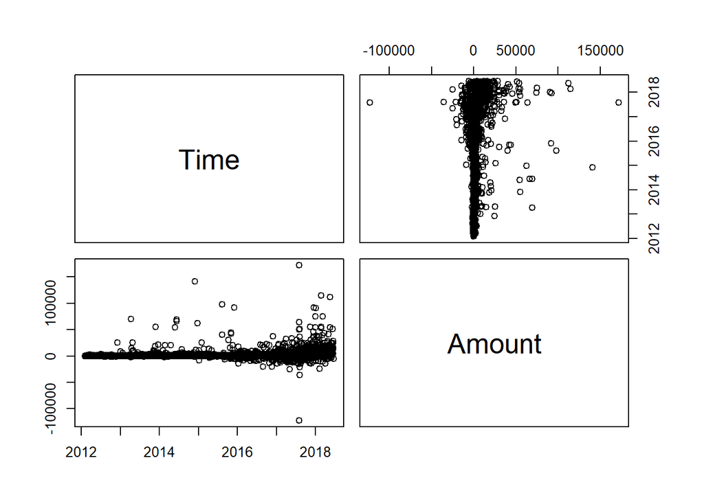

```r
pairs(opW1[,c(1,2)])
```

**Time - Amount:** Se puede apreciar que a medida que transcurren los años (Time) la cantidad de BTC (Amount) negociada por las cuentas con mayor número de BTC aumenta, además también aumenta la volatilidad de los registros.

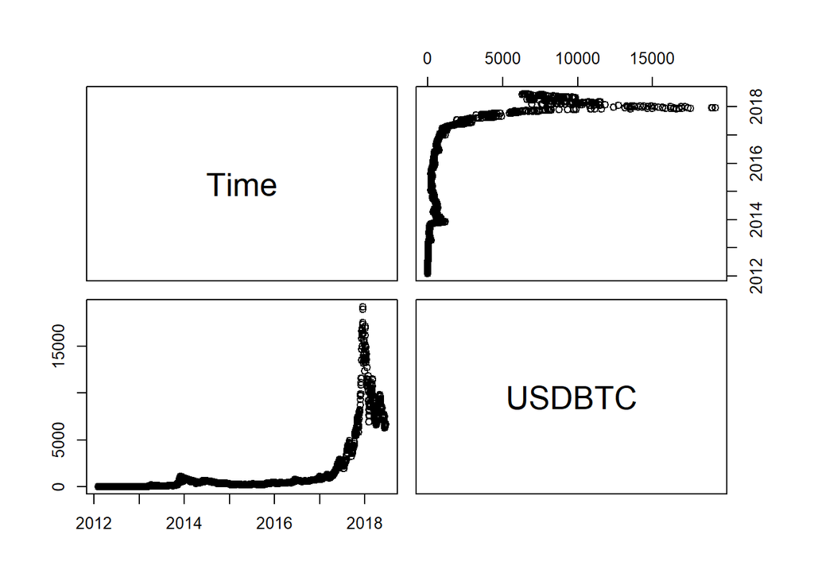

```r
pairs(opW1[,c(1,3)])
```

**Time - USDBTC:** Se ve que desde 2002 el precio del BTC ha estado por debajo de los 2000 dólares, pero a partir del 2017 el precio ha experimentado un rally alcista pasando de valores aproximados de 2000 a casi 20000 dólares por BTC.

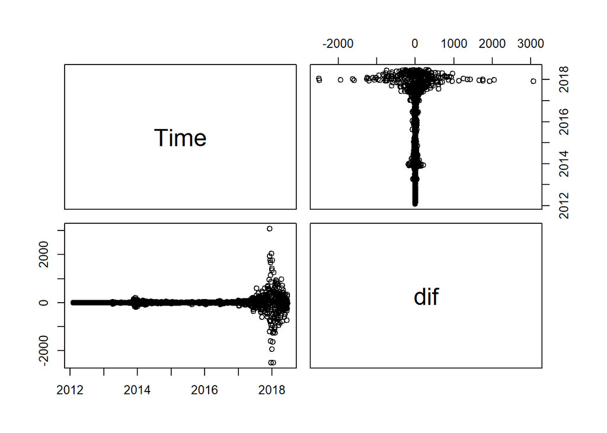

```r
pairs(opW1[,c(1,4)])
```

**Time - dif:** Las diferencias de cotización positivas o negativas del precio del BTC se ha visto incrementado notablemente a partir del 2017 llegando a superar los 3000 dólares de diferencia en un solo día y mostrando un número considerable de días en los que ha permanecido en +- 1000 dólares.

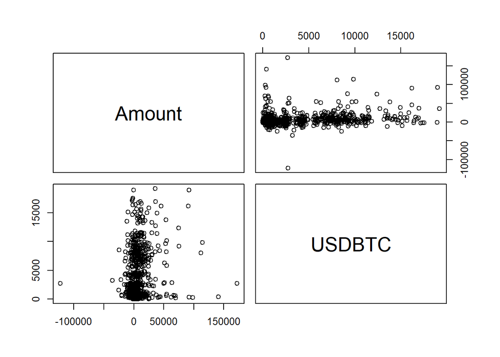

```r
pairs(opW1[,c(2,3)])
```

**Amount - USDBTC:** La mayoría de las operaciones se encuentran cuando el precio de cotización del activo (USDBTC) estaba por debajo de 2000 dólares.  
No parece a simple vista que el incremento del tamaño de las operaciones de BTC negociado (Amount) tenga un efecto en el precio del activo (USDBTC).

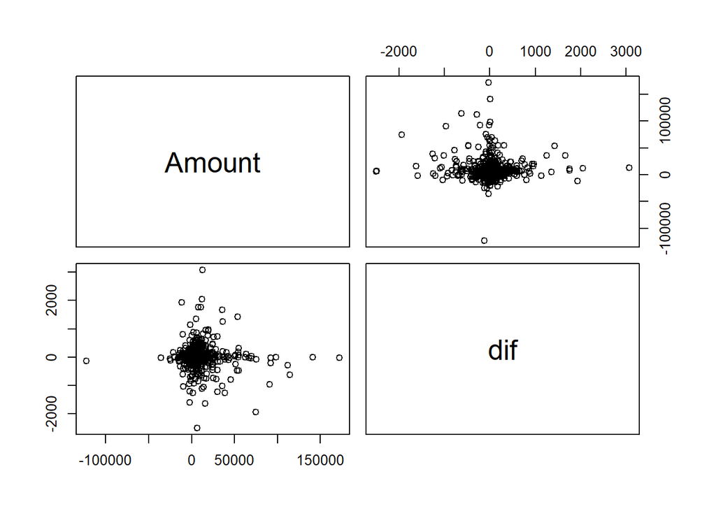

```r
pairs(opW1[,c(2,4)])
```

**Amount - Dif:** No se aprecian variaciones en las diferencias de cotización diarias con el aumento o disminución de la cantidad de BTC negociado en el día.

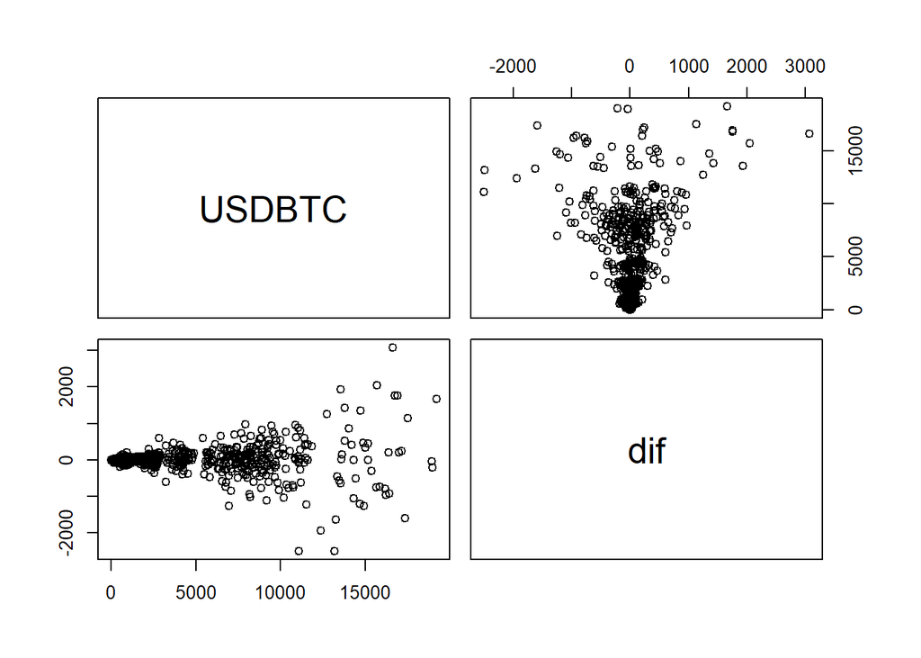

```r
pairs(opW1[,c(3,4)])
```

**USDBTC - Dif:** Se puede apreciar que las diferencias de cotización diaria aumentan a medida que aumenta el precio de cotización del activo.

### Visualización de compras y ventas en los últimos 24 meses

De la inspección de los datos llevada a cabo se aprecia que el activo BTC ha experimentado las mayores fluctuaciones de cotización a partir del 2017.  
Por este motivo se pretende evaluar para este período la cantidad de BTC comprada o vendida por los mayores tenedores de BTC.  
Para facilitar la visualización se efectuará la representación con una granularidad mensual para el período que comprende los últimos 24 meses.

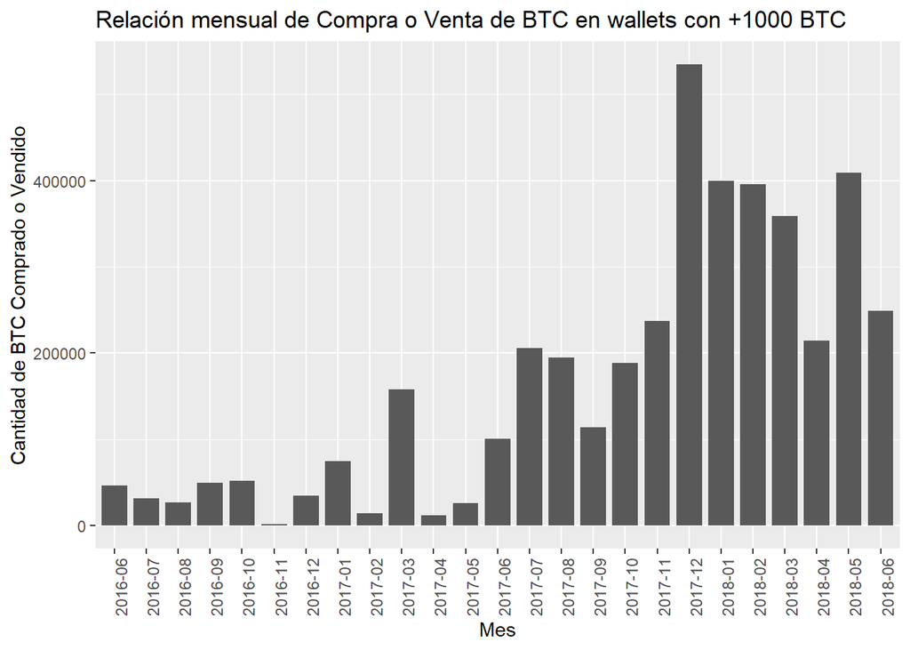

```r
#se añade la variable mes.
opW1$mes <- str_extract(opW1$Time, ".{7}")

#se realiza un sumatorio de las compras y ventas agrupadas por mes.
x <- opW1 %>% group_by(mes) %>% summarise(suma = sum(Amount))

#se grafican los últimos 24 meses de compras y ventas de BTC
#para las wallets en seguimiento

ggplot(data=x[(nrow(x)-24):nrow(x),], aes(x=mes, y=suma)) +
  geom_bar(stat="identity", width=0.8) +
  theme(axis.text.x = element_text(angle = 90, hjust = 1)) +
  labs(x="Mes",  y="Cantidad de BTC Comprado o Vendido",
         title="Relación mensual de Compra o Venta de BTC en wallets con +1000 BTC")
```

Es interesante evaluar que en global **no se presenta ningún mes** en el que los mayores poseedores de Bitcoins hayan visto reducido la cantidad de bitcoins que poseen.  
Este dato incrementa su importancia al tratarse de un período con alta volatilidad e incluyendo un fuerte descenso de la cotización del activo en el 2018.  
Se puede determinar que el precio de Bitcoin en el 2018 ha descendido,sin embargo, los mayores poseedores de Bitcoin tienen cada vez más Bitcoins.

### Regresión lineal

Aplicar algoritmo de Regresión lineal:  
Se realiza la regresión lineal entre la cantidad de BTC negociado a diario por las wallets con más de 1000 BTC y la diferencia de cotización experimentada por el precio en dólares de BTC.

```r
mod <- lm(opW1$dif ~ opW1$Amount, data = opW1)

summary(mod)
```

```
##
## Call:
## lm(formula = opW1$dif ~ opW1$Amount, data = opW1)
##
## Residuals:
##      Min       1Q   Median       3Q      Max
## -2502.78    -8.69    -4.80     3.30  3079.20
##
## Coefficients:
##               Estimate Std. Error t value Pr(>|t|)
## (Intercept)  5.1432165  4.5898696   1.121   0.2626
## opW1$Amount -0.0008298  0.0004149  -2.000   0.0456 *
## ---
## Signif. codes:  0 '***' 0.001 '**' 0.01 '*' 0.05 '.' 0.1 ' ' 1
##
## Residual standard error: 213.6 on 2299 degrees of freedom
## Multiple R-squared:  0.001737,   Adjusted R-squared:  0.001303
## F-statistic:     4 on 1 and 2299 DF,  p-value: 0.04561
```

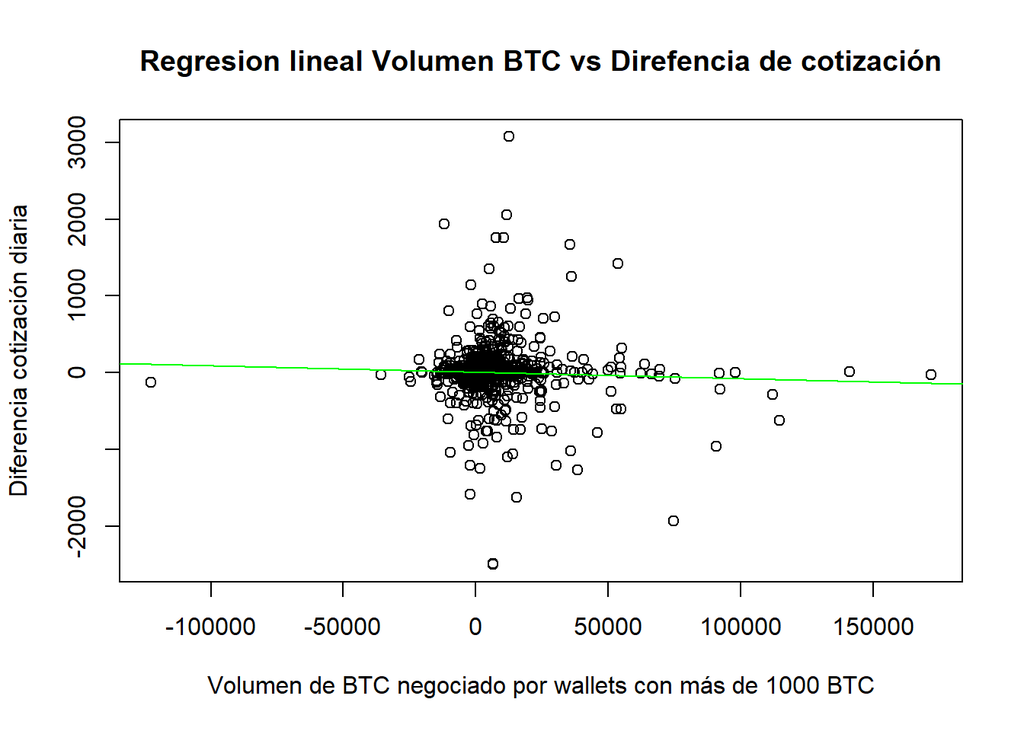

```r
plot(opW1$Amount, opW1$dif, xlab = "Volumen de BTC negociado por wallets con más de 1000 BTC", ylab = "Diferencia cotización diaria", main = "Regresion lineal Volumen BTC vs Direfencia de cotización")
abline(mod, col = "green")
```

Con el fin de conocer si el modelo calculado es válido se inspecciona el resumen del modelo entrenado:  
En él se puede ver un p-value con un valor por debajo de 0.05 lo que validaría el modelo si se considera un nivel de significancia del 95% como correcto.  
El siguiente dato a valorar es la efectividad del modelo creado, para lo que se ha de revisar el Multiple R-square, conocido como r cuadrado, este valor indica 0.001737.  
Esto indica que menos del 0,2% de la variable dependiente es explicado por la variable independiente.

**Bajo este supuesto de datos, la compra o venta de BTC por parte de las wallets con más de 1000 BTC, no permite determinar que esté afectando de una manera directa a la diferencia de cotización experimentado por el BTC en el mismo día de haberse negociado.**